# Customer Churn Forecasting in Telecommunication Industry

# 1. Introduction

Considering the difference between costs of obtaining new customers and retaining existing customers, customer churn is a significant problem in business life.  
Companies struggle to launch special marketing campaigns in order to retain customers.  
Identifying customers which will leave the company soon may be a competitive advantage for companies.  
The aim of this analysis is to predict customer churn and identify customers which will leave the company soon since company wants to launch new marketing campaign for them in this scenario.  
Each row represents a customer, each column contains customers' attributes.  
The raw data contains 7043 rows (customers) and 21 columns (features).  
The 'Churn' column is our target.  
The data set includes information about:

Customers who left within the last month – the column is called Churn  
Services that each customer has signed up for – phone, multiple lines, Internet, online security, online backup, device protection, tech support, and streaming TV and movies  
Customer account information – how long they have been a customer, contract, payment method, paperless billing, monthly charges, and total charges  
Demographic info about customers – gender, age range, and if they have partners and dependents

- customerID : The Customer ID
- Gender : Whether the customer is a male or a female
- SeniorCitizen : Whether the customer is a senior citizen or not (1, 0)
- Partner : Whether the customer has a partner or not (Yes, No)
- Dependents : Whether the customer has dependents or not (Yes, No)
- tenure : Number of months the customer has stayed with the company
- PhoneService : Whether the customer has a phone service or not (Yes, No)
- MultipleLines : Whether the customer has multiple lines or not (Yes, No, No phone service)
- InternetService : Customer’s internet service provider (DSL, Fiber optic, No)
- OnlineSecurity : Whether the customer has online security or not (Yes, No, No internet service)
- OnlineBackup : Whether the customer has online backup or not (Yes, No, No internet service)
- DeviceProtection : Whether the customer has device protection or not (Yes, No, No internet service)
- TechSupport : Whether the customer has tech support or not (Yes, No, No internet service)
- StreamingTV : Whether the customer has streaming TV or not (Yes, No, No internet service)
- StreamingMovies : Whether the customer has streaming movies or not (Yes, No, No internet service)
- Contract : The contract term of the customer (Month-to-month, One year, Two year)
- Paperless : BillingWhether the customer has paperless billing or not (Yes, No)
- PaymentMethod : The customer’s payment method (Electronic check, Mailed check, Bank transfer, Credit card
- MonthlyCharges : The amount charged to the customer monthly
- TotalCharges : The total amount charged to the customer
- Churn : Whether the customer churned or not (Yes or No)

Importing libraries:

```python
import pandas as pd
import numpy as np
import seaborn as sns
import matplotlib.pyplot as plt
%matplotlib inline

from scipy import stats

from sklearn.preprocessing import LabelEncoder, OneHotEncoder, StandardScaler
from sklearn.feature_selection import SelectFromModel
from sklearn.model_selection import train_test_split, KFold, GridSearchCV

from sklearn.naive_bayes import GaussianNB
from sklearn.tree import DecisionTreeClassifier
from sklearn import tree
from sklearn.linear_model import LogisticRegression
from sklearn.neighbors import KNeighborsClassifier
from sklearn.svm import LinearSVC
from sklearn.ensemble import RandomForestClassifier
from sklearn.ensemble import GradientBoostingClassifier

from sklearn.metrics import confusion_matrix,accuracy_score,classification_report
from sklearn.metrics import roc_auc_score, log_loss, precision_score, recall_score, f1_score, make_scorer

import warnings
warnings.filterwarnings('ignore')
pd.options.mode.chained_assignment = None
pd.options.display.max_columns = None
```

Reading the data file:

```python
raw_data = pd.read_csv('WA_Fn-UseC_-Telco-Customer-Churn.csv')
```

The number of rows and columns of the data:

```python
raw_data.shape
```

```
(7043, 21)
```

The raw data contains 7043 rows (customers) and 21 columns (features).

Enabling Jupyter Notebook to show all columns in outputs and looking at the first/last 5 rows of data:

```python
raw_data.head()
```

|  | customerID | Gender | SeniorCitizen | Partner | Dependents | tenure | PhoneService | MultipleLines | InternetService | OnlineSecurity | OnlineBackup | DeviceProtection | TechSupport | StreamingTV | StreamingMovies | Contract | PaperlessBilling | PaymentMethod | MonthlyCharges | TotalCharges | Churn |
| --- | --- | --- | --- | --- | --- | --- | --- | --- | --- | --- | --- | --- | --- | --- | --- | --- | --- | --- | --- | --- | --- |
| 0 | 7590-VHVEG | Female | 0 | Yes | No | 1 | No | No phone service | DSL | No | Yes | No | No | No | No | Month-to-month | Yes | Electronic check | 29.85 | 29.85 | No |
| 1 | 5575-GNVDE | Male | 0 | No | No | 34 | Yes | No | DSL | Yes | No | Yes | No | No | No | One year | No | Mailed check | 56.95 | 1889.5 | No |
| 2 | 3668-QPYBK | Male | 0 | No | No | 2 | Yes | No | DSL | Yes | Yes | No | No | No | No | Month-to-month | Yes | Mailed check | 53.85 | 108.15 | Yes |
| 3 | 7795-CFOCW | Male | 0 | No | No | 45 | No | No phone service | DSL | Yes | No | Yes | Yes | No | No | One year | No | Bank transfer (automatic) | 42.30 | 1840.75 | No |
| 4 | 9237-HQITU | Female | 0 | No | No | 2 | Yes | No | Fiber optic | No | No | No | No | No | No | Month-to-month | Yes | Electronic check | 70.70 | 151.65 | Yes |

```python
raw_data.tail()
```

|  | customerID | Gender | SeniorCitizen | Partner | Dependents | tenure | PhoneService | MultipleLines | InternetService | OnlineSecurity | OnlineBackup | DeviceProtection | TechSupport | StreamingTV | StreamingMovies | Contract | PaperlessBilling | PaymentMethod | MonthlyCharges | TotalCharges | Churn |
| --- | --- | --- | --- | --- | --- | --- | --- | --- | --- | --- | --- | --- | --- | --- | --- | --- | --- | --- | --- | --- | --- |
| 7038 | 6840-RESVB | Male | 0 | Yes | Yes | 24 | Yes | Yes | DSL | Yes | No | Yes | Yes | Yes | Yes | One year | Yes | Mailed check | 84.80 | 1990.5 | No |
| 7039 | 2234-XADUH | Female | 0 | Yes | Yes | 72 | Yes | Yes | Fiber optic | No | Yes | Yes | No | Yes | Yes | One year | Yes | Credit card (automatic) | 103.20 | 7362.9 | No |
| 7040 | 4801-JZAZL | Female | 0 | Yes | Yes | 11 | No | No phone service | DSL | Yes | No | No | No | No | No | Month-to-month | Yes | Electronic check | 29.60 | 346.45 | No |
| 7041 | 8361-LTMKD | Male | 1 | Yes | No | 4 | Yes | Yes | Fiber optic | No | No | No | No | No | No | Month-to-month | Yes | Mailed check | 74.40 | 306.6 | Yes |
| 7042 | 3186-AJIEK | Male | 0 | No | No | 66 | Yes | No | Fiber optic | Yes | No | Yes | Yes | Yes | Yes | Two year | Yes | Bank transfer (automatic) | 105.65 | 6844.5 | No |

# 2. Data Preparation

## 2.1. Identification of Variables & Data Types

```python
raw_data.info()
```

```
<class 'pandas.core.frame.DataFrame'>
RangeIndex: 7043 entries, 0 to 7042
Data columns (total 21 columns):
customerID          7043 non-null object
Gender              7043 non-null object
SeniorCitizen       7043 non-null int64
Partner             7043 non-null object
Dependents          7043 non-null object
tenure              7043 non-null int64
PhoneService        7043 non-null object
MultipleLines       7043 non-null object
InternetService     7043 non-null object
OnlineSecurity      7043 non-null object
OnlineBackup        7043 non-null object
DeviceProtection    7043 non-null object
TechSupport         7043 non-null object
StreamingTV         7043 non-null object
StreamingMovies     7043 non-null object
Contract            7043 non-null object
PaperlessBilling    7043 non-null object
PaymentMethod       7043 non-null object
MonthlyCharges      7043 non-null float64
TotalCharges        7043 non-null object
Churn               7043 non-null object
dtypes: float64(1), int64(2), object(18)
memory usage: 1.1+ MB
```

It can be understood that most of the variables have object data type, there are 2 variables which have int data type and there is 1 variable with float data type.

The number of distinct values of each column:

```python
raw_data.apply(lambda x: [x.nunique()])
```

```
customerID          [7043]
Gender                 [2]
SeniorCitizen          [2]
Partner                [2]
Dependents             [2]
tenure                [73]
PhoneService           [2]
MultipleLines          [3]
InternetService        [3]
OnlineSecurity         [3]
OnlineBackup           [3]
DeviceProtection       [3]
TechSupport            [3]
StreamingTV            [3]
StreamingMovies        [3]
Contract               [3]
PaperlessBilling       [2]
PaymentMethod          [4]
MonthlyCharges      [1585]
TotalCharges        [6531]
Churn                  [2]
dtype: object
```

The distinct values of each column:

```python
raw_data.apply(lambda x: [x.unique()])
```

```
customerID          [[7590-VHVEG, 5575-GNVDE, 3668-QPYBK, 7795-CFO...
Gender                                               [[Female, Male]]
SeniorCitizen                                                [[0, 1]]
Partner                                                   [[Yes, No]]
Dependents                                                [[No, Yes]]
tenure              [[1, 34, 2, 45, 8, 22, 10, 28, 62, 13, 16, 58,...
PhoneService                                              [[No, Yes]]
MultipleLines                           [[No phone service, No, Yes]]
InternetService                              [[DSL, Fiber optic, No]]
OnlineSecurity                       [[No, Yes, No internet service]]
OnlineBackup                         [[Yes, No, No internet service]]
DeviceProtection                     [[No, Yes, No internet service]]
TechSupport                          [[No, Yes, No internet service]]
StreamingTV                          [[No, Yes, No internet service]]
StreamingMovies                      [[No, Yes, No internet service]]
Contract                       [[Month-to-month, One year, Two year]]
PaperlessBilling                                          [[Yes, No]]
PaymentMethod       [[Electronic check, Mailed check, Bank transfe...
MonthlyCharges      [[29.85, 56.95, 53.85, 42.3, 70.7, 99.65, 89.1...
TotalCharges        [[29.85, 1889.5, 108.15, 1840.75, 151.65, 820....
Churn                                                     [[No, Yes]]
dtype: object
```

Outputs illustrates that the most of the variables(18/21) are categorical and have 4 distinct values at most. 'Churn' is target variable and the other variables are predictors.

'tenure', 'MontlyCharges' and 'TotalCharges' are numerical variables of the data.

Although type of 'TotalCharges' should be float, it's type is object.  
It may have some string values.

```python
raw_data['TotalCharges'].sort_values().head(20)
```

```
936
3826
4380
753
5218
3331
6754
6670
1340
488
1082
105       100.2
4459     100.25
1723     100.35
2124      100.4
2208      100.8
460       100.9
3883     1001.2
2799     1001.5
5337    1003.05
Name: TotalCharges, dtype: object
```

There are 11 rows which contain empty values in 'TotalCharges' column.  
Thus, it's type will be transformed to float after missing value treatment process in Exploratory Data Analysis step.

## 2.2. Variable Transformations

First of all, 'customerID' column will be dropped since it is ineffective for the analysis.

```python
data = raw_data.drop('customerID', axis=1)
```

```python
data.info()
```

```
<class 'pandas.core.frame.DataFrame'>
RangeIndex: 7043 entries, 0 to 7042
Data columns (total 20 columns):
Gender              7043 non-null object
SeniorCitizen       7043 non-null int64
Partner             7043 non-null object
Dependents          7043 non-null object
tenure              7043 non-null int64
PhoneService        7043 non-null object
MultipleLines       7043 non-null object
InternetService     7043 non-null object
OnlineSecurity      7043 non-null object
OnlineBackup        7043 non-null object
DeviceProtection    7043 non-null object
TechSupport         7043 non-null object
StreamingTV         7043 non-null object
StreamingMovies     7043 non-null object
Contract            7043 non-null object
PaperlessBilling    7043 non-null object
PaymentMethod       7043 non-null object
MonthlyCharges      7043 non-null float64
TotalCharges        7043 non-null object
Churn               7043 non-null object
dtypes: float64(1), int64(2), object(17)
memory usage: 1.1+ MB
```

Replacing 1 and 0 values in the 'SeniorCitizen' column with 'Yes' and 'No' since it is a categorical feature.

```python
data['SeniorCitizen'] = data['SeniorCitizen'].replace({1:'Yes',0:'No'})
```

Renaming 'tenure' column:

```python
data = data.rename(columns={'tenure':'Tenure'})
```

```python
data['MultipleLines'] = data['MultipleLines'].replace({'No phone service' : 'No'})

for i in range(8, 14):
    data.iloc[:, i] = data.iloc[:, i].replace({'No internet service' : 'No'})
```

# 3. Exploratory Data Analysis

## 3.1. Missing Value Treatment

Replacing empty values with na in the data:

Let's see the na values:

```python
data = data.replace('', np.nan)
data = data.replace(' ', np.nan)
```

```python
data[data.isnull().any(axis=1)]
```

|  | Gender | SeniorCitizen | Partner | Dependents | Tenure | PhoneService | MultipleLines | InternetService | OnlineSecurity | OnlineBackup | DeviceProtection | TechSupport | StreamingTV | StreamingMovies | Contract | PaperlessBilling | PaymentMethod | MonthlyCharges | TotalCharges | Churn |
| --- | --- | --- | --- | --- | --- | --- | --- | --- | --- | --- | --- | --- | --- | --- | --- | --- | --- | --- | --- | --- |
| 488 | Female | No | Yes | Yes | 0 | No | No | DSL | Yes | No | Yes | Yes | Yes | No | Two year | Yes | Bank transfer (automatic) | 52.55 | NaN | No |
| 753 | Male | No | No | Yes | 0 | Yes | No | No | No | No | No | No | No | No | Two year | No | Mailed check | 20.25 | NaN | No |
| 936 | Female | No | Yes | Yes | 0 | Yes | No | DSL | Yes | Yes | Yes | No | Yes | Yes | Two year | No | Mailed check | 80.85 | NaN | No |
| 1082 | Male | No | Yes | Yes | 0 | Yes | Yes | No | No | No | No | No | No | No | Two year | No | Mailed check | 25.75 | NaN | No |
| 1340 | Female | No | Yes | Yes | 0 | No | No | DSL | Yes | Yes | Yes | Yes | Yes | No | Two year | No | Credit card (automatic) | 56.05 | NaN | No |
| 3331 | Male | No | Yes | Yes | 0 | Yes | No | No | No | No | No | No | No | No | Two year | No | Mailed check | 19.85 | NaN | No |
| 3826 | Male | No | Yes | Yes | 0 | Yes | Yes | No | No | No | No | No | No | No | Two year | No | Mailed check | 25.35 | NaN | No |
| 4380 | Female | No | Yes | Yes | 0 | Yes | No | No | No | No | No | No | No | No | Two year | No | Mailed check | 20.00 | NaN | No |
| 5218 | Male | No | Yes | Yes | 0 | Yes | No | No | No | No | No | No | No | No | One year | Yes | Mailed check | 19.70 | NaN | No |
| 6670 | Female | No | Yes | Yes | 0 | Yes | Yes | DSL | No | Yes | Yes | Yes | Yes | No | Two year | No | Mailed check | 73.35 | NaN | No |
| 6754 | Male | No | No | Yes | 0 | Yes | Yes | DSL | Yes | Yes | No | Yes | No | No | Two year | Yes | Bank transfer (automatic) | 61.90 | NaN | No |

```python
data['TotalCharges'] = data['TotalCharges'].fillna(0)
```

11 rows which have na value represent very small proportion in 7043 rows. Since tenure of the rows are 0, they can be filled with 0 to obtain missing value treatment.

```python
data.isna().sum()
```

```
Gender              0
SeniorCitizen       0
Partner             0
Dependents          0
Tenure              0
PhoneService        0
MultipleLines       0
InternetService     0
OnlineSecurity      0
OnlineBackup        0
DeviceProtection    0
TechSupport         0
StreamingTV         0
StreamingMovies     0
Contract            0
PaperlessBilling    0
PaymentMethod       0
MonthlyCharges      0
TotalCharges        0
Churn               0
dtype: int64
```

Changing the data type of 'TotalCharges':

```python
data['TotalCharges'] = data['TotalCharges'].astype(float)
```

## 3.2. Outlier Treatment

Identifying the outliers in continuous variables based on IQR Score Method:

```python
def find_outliers(data, column_list):
    for i in column_list:
        Q1 = data[i].quantile(0.25)
        Q3 = data[i].quantile(0.75)
        IQR = Q3 - Q1
        print(data[i][(data[i] < (Q1 - 1.5 * IQR)) | (data[i] > (Q3 + 1.5 * IQR))])
find_outliers(data, ['Tenure', 'MonthlyCharges', 'TotalCharges'])
```

```
Series([], Name: Tenure, dtype: int64)
Series([], Name: MonthlyCharges, dtype: float64)
Series([], Name: TotalCharges, dtype: float64)
```

It can be seen that columns do not contain any outliers.

## 3.3. Univariate Analysis

Firstly, target variable should be set and other variables should be split into 2 groups as categorical and numerical variables to make the analysis easier.

```python
features = data.drop('Churn', axis=1)
target = pd.DataFrame(data['Churn'], columns=['Churn'])
```

```python
nums = features.select_dtypes(['int64', 'float64'])
cats = features.select_dtypes(['object'])
```

### 3.3.1. Categorical

**Count%**

```python
round(target['Churn'].value_counts(normalize=True), 2)
```

```
No     0.73
Yes    0.27
Name: Churn, dtype: float64
```

The customers who stop doing business with the company represent %27 of the data.  
Hence, it can be said that this is an unbalanced data.

```python
for i in cats.columns:
    print(round(cats[i].value_counts(normalize=True), 2))
    print('\n')
```

```
Male      0.5
Female    0.5
Name: Gender, dtype: float64


No     0.84
Yes    0.16
Name: SeniorCitizen, dtype: float64


No     0.52
Yes    0.48
Name: Partner, dtype: float64


No     0.7
Yes    0.3
Name: Dependents, dtype: float64


Yes    0.9
No     0.1
Name: PhoneService, dtype: float64


No     0.58
Yes    0.42
Name: MultipleLines, dtype: float64


Fiber optic    0.44
DSL            0.34
No             0.22
Name: InternetService, dtype: float64


No     0.71
Yes    0.29
Name: OnlineSecurity, dtype: float64

```

[output cut: 27 more lines]

```
Two year          0.24
One year          0.21
Name: Contract, dtype: float64


Yes    0.59
No     0.41
Name: PaperlessBilling, dtype: float64


Electronic check             0.34
Mailed check                 0.23
Bank transfer (automatic)    0.22
Credit card (automatic)      0.22
Name: PaymentMethod, dtype: float64
```

**Pie Chart**

```
		Gender
```

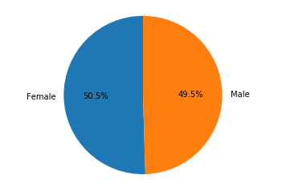

```
---------------------------------------------


		SeniorCitizen
```

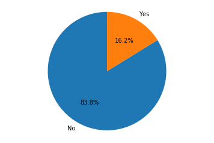

```
---------------------------------------------


		Partner
```

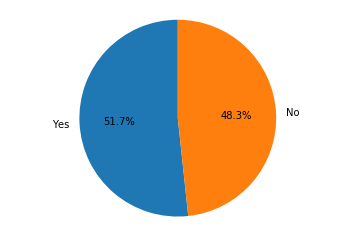

```
---------------------------------------------


		Dependents
```

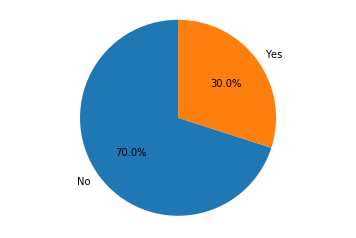

```
---------------------------------------------


		PhoneService
```

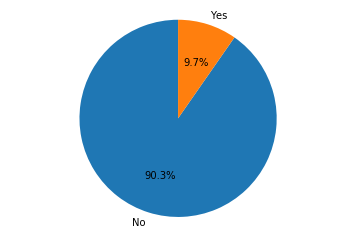

```
---------------------------------------------


		MultipleLines
```

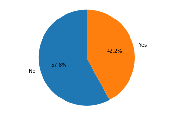

```
---------------------------------------------


		InternetService
```

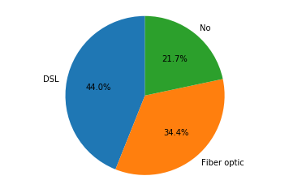

```
---------------------------------------------


		OnlineSecurity
```

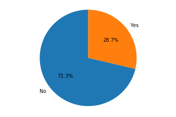

```
---------------------------------------------


		OnlineBackup
```

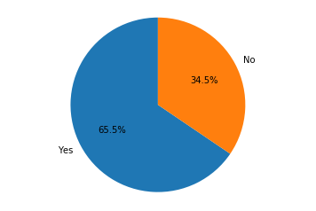

```
---------------------------------------------


		DeviceProtection
```

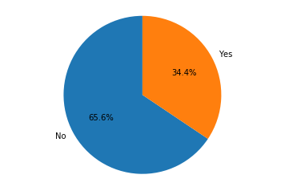

```
---------------------------------------------


		TechSupport
```

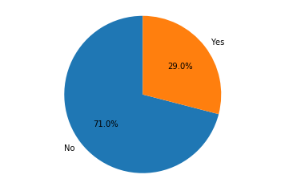

```
---------------------------------------------


		StreamingTV
```

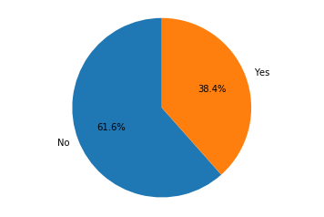

```
---------------------------------------------


		StreamingMovies
```

[4 more figures not shown]

```python
for i in cats.columns:
    print('\n')
    print('\t'*2 + i)
    plt.pie(cats[i].value_counts(normalize = True), labels=cats[i].unique(), autopct='%1.1f%%', startangle=90)
    plt.axis('equal')
    plt.show()
    print('-'*45)
```

The outputs show that while some variables are balanced some are imbalanced. The imbalanced variables are as below:  
84% of the customers are not senior citizen.  
70% of the customers does not have dependents.  
71% of the customers does not have online security.  
71% of the customers does not have tech support.  
90% of the customers have phone service.

### 3.3.2. Numerical

```python
nums.describe()
```

|  | Tenure | MonthlyCharges | TotalCharges |
| --- | --- | --- | --- |
| count | 7043.000000 | 7043.000000 | 7043.000000 |
| mean | 32.371149 | 64.761692 | 2279.734304 |
| std | 24.559481 | 30.090047 | 2266.794470 |
| min | 0.000000 | 18.250000 | 0.000000 |
| 25% | 9.000000 | 35.500000 | 398.550000 |
| 50% | 29.000000 | 70.350000 | 1394.550000 |
| 75% | 55.000000 | 89.850000 | 3786.600000 |
| max | 72.000000 | 118.750000 | 8684.800000 |

```python
print('-----Variance-----')
for i in nums.columns:
    print(i + ': ' + str(round(nums[i].var(), 2)))
```

```
-----Variance-----
Tenure: 603.17
MonthlyCharges: 905.41
TotalCharges: 5138357.17
```

```python
print('-----Coefficient of Variation-----')
for i in nums.columns:
    print(i + ': ' + str(round((nums[i].std() / nums[i].mean()) * 100, 2)))
```

```
-----Coefficient of Variation-----
Tenure: 75.87
MonthlyCharges: 46.46
TotalCharges: 99.43
```

```python
nums.skew()
```

```
Tenure            0.239540
MonthlyCharges   -0.220524
TotalCharges      0.963235
dtype: float64
```

Since the outputs of the 'Tenure' and 'MonthlyCharges' variables are between -0.5 and 0 or 0 and 0.5 it can be said that these variables have symmetrical distribution. However, the output of the 'TotalCharges' variable is between 0.5 and 1, thus this variable is moderately (and positively) skewed.

```python
nums.kurtosis()
```

```
Tenure           -1.387372
MonthlyCharges   -1.257260
TotalCharges     -0.228580
dtype: float64
```

All variables have low kurtosis which is an indicator that data has light tails or lack of outliers. In addition, distribution is shorter, tails are thinner than the normal distribution.

**Histogram, Box Plot**

```
array([[<matplotlib.axes._subplots.AxesSubplot object at 0x1a181e5ef0>,
      dtype=object)
```

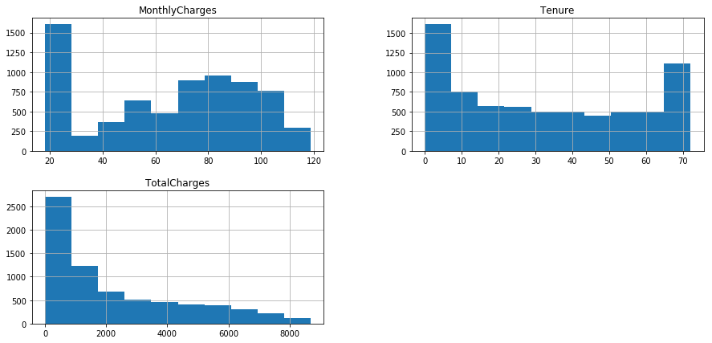

```python
nums.hist(bins=10, figsize=(15, 7))
```

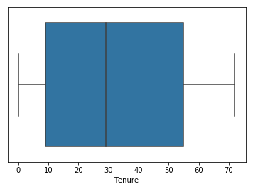

```python
sns.boxplot(x=nums['Tenure'])
```

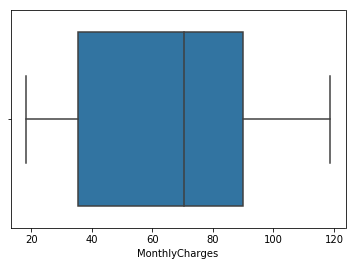

```python
sns.boxplot(x=nums['MonthlyCharges'])
```

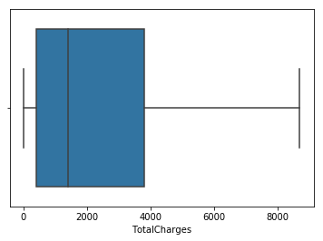

```python
sns.boxplot(x=nums['TotalCharges'])
```

## 3.4. Bivariate Analysis

### 3.4.1. Categorical & Categorical

**Chi-Square Test**

```python
same = []
for i in cats.columns:
    cont = pd.crosstab(cats[i], target['Churn'])
    chi2_stat, p_val, dof, ex = stats.chi2_contingency(cont)
    print(i + ' - Churn')
    print("Chi2 Stat :" + str(chi2_stat))
    print("Critical Value :" + str(stats.chi2.ppf(q = 0.95, df = dof)))
    if chi2_stat < stats.chi2.ppf(q = 0.95, df = dof):
        same.append(i)
    print("P-Value :" + str(p_val))
    print("Contingency Table :" + str(ex))
    print('\n')
```

```
Gender - Churn
Chi2 Stat :0.4840828822091383
Critical Value :3.841458820694124
P-Value :0.48657873605618596
Contingency Table :[[2562.38989067  925.61010933]
 [2611.61010933  943.38989067]]


SeniorCitizen - Churn
Chi2 Stat :159.42630036838742
Critical Value :3.841458820694124
P-Value :1.510066805092378e-36
Contingency Table :[[4335.05239245 1565.94760755]
 [ 838.94760755  303.05239245]]


Partner - Churn
Chi2 Stat :158.7333820309922
Critical Value :3.841458820694124
P-Value :2.1399113440759935e-36
Contingency Table :[[2674.78830044  966.21169956]
 [2499.21169956  902.78830044]]


Dependents - Churn
Chi2 Stat :189.12924940423474
Critical Value :3.841458820694124
P-Value :4.9249216612154196e-43
Contingency Table :[[3623.93042737 1309.06957263]
 [1550.06957263  559.93042737]]


PhoneService - Churn
Chi2 Stat :0.9150329892546948
Critical Value :3.841458820694124
P-Value :0.3387825358066928
Contingency Table :[[ 501.01774812  180.98225188]
 [4672.98225188 1688.01774812]]


```

[output cut: 75 more lines]

```
Chi2 Stat :258.27764906707307
Critical Value :3.841458820694124
P-Value :4.073354668665985e-58
Contingency Table :[[2109.85773108  762.14226892]
 [3064.14226892 1106.85773108]]


PaymentMethod - Churn
Chi2 Stat :648.1423274814
Critical Value :7.814727903251179
P-Value :3.6823546520097993e-140
Contingency Table :[[1134.26891949  409.73108051]
 [1118.10705665  403.89294335]
 [1737.40025557  627.59974443]
 [1184.22376828  427.77623172]]
```

```python
same
```

```
['Gender', 'PhoneService']
```

**Bar Charts**

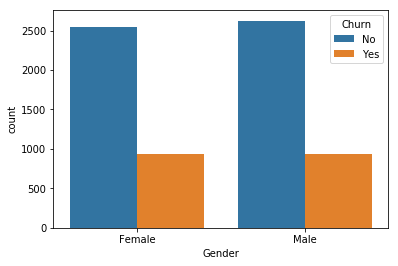

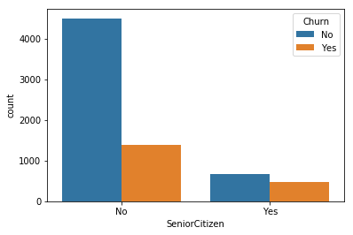

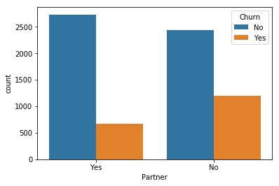

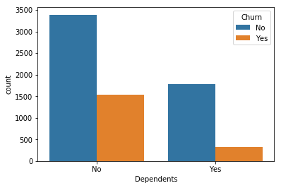

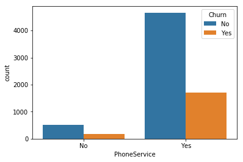

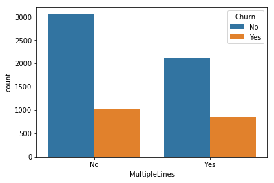

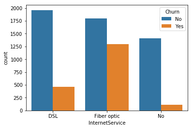

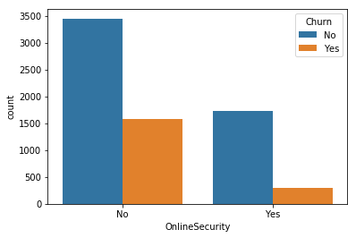

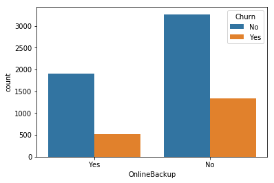

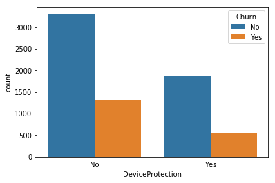

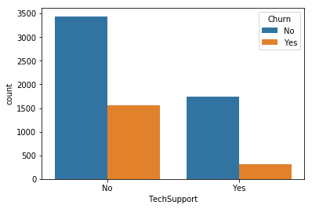

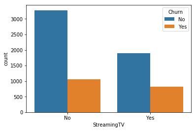

[4 more figures not shown]

```python
def categorical_summarized(dataframe, x=None, y=None, hue=None, verbose=True):
    sns.countplot(x=x, y=y, hue=hue, data=dataframe)
    plt.show()

for i in cats.columns:
    categorical_summarized(data, x = i, hue='Churn')
```

### 3.4.2. Numerical & Numerical

**Correlation**

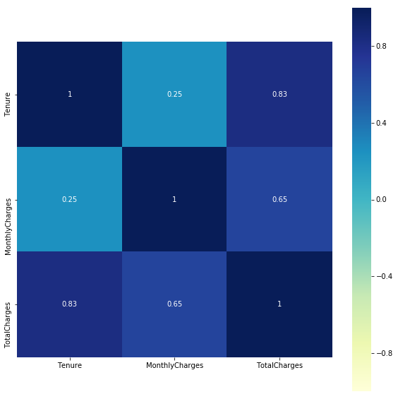

```python
plt.figure(figsize=(10, 10))
sns.heatmap(nums.corr(), vmin=-1, vmax=1, center=0, annot=True, cmap='YlGnBu', square=True);
```

**Scatter Plot**

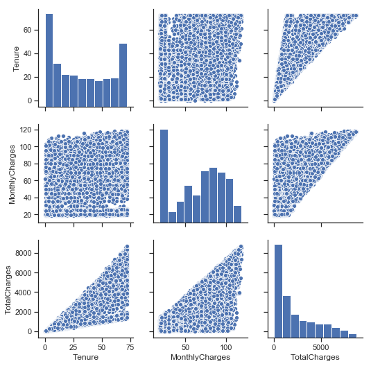

```python
sns.set(style='ticks')
sns.pairplot(nums);
```

### 3.4.3. Numerical & Categorical

```python
data['Churn'] = data['Churn'].replace({'Yes':1,'No':0})
data.groupby('Tenure')['Churn'].mean().sort_values(ascending=False).head(5)
```

```
Tenure
1    0.619902
2    0.516807
5    0.481203
4    0.471591
3    0.470000
Name: Churn, dtype: float64
```

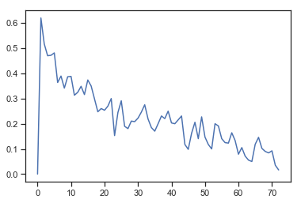

```python
plt.plot(pd.DataFrame(data['Tenure'].unique(), columns=['Tenure']).sort_values(by='Tenure'),
         data.groupby('Tenure')['Churn'].mean())
plt.show()
```

It can be seen that there is negative relationship between 'Tenure' and 'Churn'.

**Bar Charts**

```
array([<matplotlib.axes._subplots.AxesSubplot object at 0x1a18006438>,
      dtype=object)
```

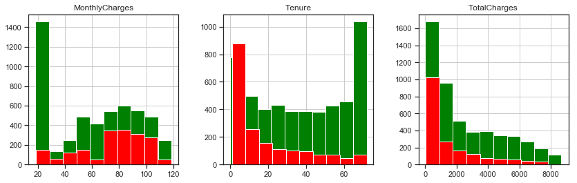

```python
fig, ax = plt.subplots(1, 3, figsize=(14, 4))
data[data['Churn'] == 0][['Tenure', 'MonthlyCharges', 'TotalCharges']].hist(bins=10,
                                                                               color='green',
                                                                               ax=ax)
data[data['Churn'] == 1][['Tenure', 'MonthlyCharges', 'TotalCharges']].hist(bins=10,
                                                                                color='red',
                                                                                ax=ax)
```

# 4. Data Preprocessing

## 4.1. Label Encoding

```python
le = LabelEncoder()

target['Churn'] = le.fit_transform(target['Churn'])

for i in cats.columns:
    if features[i].nunique() == 2:
        features[i] = le.fit_transform(features[i])
```

## 4.2. Dummification

```python
for i in cats.columns:
    if features[i].nunique() > 2:
        cols = []
        for j in list(features[i].unique()):
            cols.append(i + ':' + j)
        ohe = OneHotEncoder(dtype='int64', sparse=False)
        ohe_i = ohe.fit_transform(features[i].values.reshape(-1, 1))
        ohe_i = pd.DataFrame(ohe_i, columns=cols)
        features = pd.concat([features, ohe_i], axis=1)
        features = features.drop(i, axis=1)
```

## 4.3. Feature Scaling

Since there is no outlier in dataset, standartization is a good way to improve the performance of our model.

```python
std = StandardScaler()
scaled = std.fit_transform(features[nums.columns])
scaled = pd.DataFrame(scaled, index=features.index, columns = nums.columns)

for i in nums.columns:
    features[i] = scaled[i]
```

```python
features.apply(lambda x: [sorted(x.unique())])
```

```
Gender                                                                          [[0.0, 1.0]]
SeniorCitizen                                                                   [[0.0, 1.0]]
Partner                                                                         [[0.0, 1.0]]
Dependents                                                                      [[0.0, 1.0]]
Tenure                                     [[-1.318164947398796, -1.2774445836787656, -1....
PhoneService                                                                    [[0.0, 1.0]]
MultipleLines                                                                   [[0.0, 1.0]]
OnlineSecurity                                                                  [[0.0, 1.0]]
OnlineBackup                                                                    [[0.0, 1.0]]
DeviceProtection                                                                [[0.0, 1.0]]
TechSupport                                                                     [[0.0, 1.0]]
StreamingTV                                                                     [[0.0, 1.0]]
StreamingMovies                                                                 [[0.0, 1.0]]
PaperlessBilling                                                                [[0.0, 1.0]]
MonthlyCharges                             [[-1.5458598200734601, -1.5408744290729617, -1...
TotalCharges                               [[-1.005779833710855, -0.9974855948409108, -0....
InternetService:DSL                                                             [[0.0, 1.0]]
InternetService:Fiber optic                                                     [[0.0, 1.0]]
InternetService:No                                                              [[0.0, 1.0]]
Contract:Month-to-month                                                         [[0.0, 1.0]]
Contract:One year                                                               [[0.0, 1.0]]
Contract:Two year                                                               [[0.0, 1.0]]
PaymentMethod:Electronic check                                                  [[0.0, 1.0]]
PaymentMethod:Mailed check                                                      [[0.0, 1.0]]
PaymentMethod:Bank transfer (automatic)                                         [[0.0, 1.0]]
PaymentMethod:Credit card (automatic)                                           [[0.0, 1.0]]
dtype: object
```

## 4.4. Train-Test Split

```python
x_train_val, x_test, y_train_val, y_test = train_test_split(features, target, test_size=0.2, random_state=0)
x_train, x_val, y_train, y_val = train_test_split(x_train_val, y_train_val, test_size=0.25, random_state=0)
```

```python
print('x_train : {0:.{1}f}%'.format(x_train.shape[0] / features.shape[0] * 100, 0))
print('y_train : {0:.{1}f}%'.format(y_train.shape[0] / target.shape[0] * 100, 0))
print('\n')
print('x_val   : {0:.{1}f}%'.format(x_val.shape[0] / features.shape[0] * 100, 0))
print('y_val   : {0:.{1}f}%'.format(y_val.shape[0] / target.shape[0] * 100, 0))
print('\n')
print('x_test  : {0:.{1}f}%'.format(x_test.shape[0] / features.shape[0] * 100, 0))
print('y_test  : {0:.{1}f}%'.format(y_test.shape[0] / target.shape[0] * 100, 0))
```

```
x_train : 60%
y_train : 60%


x_val   : 20%
y_val   : 20%


x_test  : 20%
y_test  : 20%
```

# 5. Modelling

```python
classifiers = {'Naive Bayes': GaussianNB(),
               'Decision Tree': DecisionTreeClassifier(criterion='entropy'),
               'Logistic Reg.': LogisticRegression(),
               'K-Nearset N.': KNeighborsClassifier(n_jobs=-1),
               'Linear SVC' : LinearSVC(max_iter=10000),
               'Random Forest' : RandomForestClassifier(criterion='entropy', n_jobs=-1),
               'Gradient B.T.': GradientBoostingClassifier()}
```

```python
model_names = list(classifiers.keys())
accuracy = []
roc_auc = []
log_loss_list = []
f1_score_list = []
precision = []
recall = []
```

```python
for clf in classifiers:
    model = classifiers[clf]
    model.fit(x_train, y_train)
    y_pred = model.predict(x_val)
    print(clf, '\n')
    print('Accuracy Score :' + str(accuracy_score(y_val, y_pred)) + '\n')
    accuracy.append(accuracy_score(y_val, y_pred))
    print('Precision Score :' + str(precision_score(y_val, y_pred)) + '\n')
    precision.append(precision_score(y_val, y_pred))
    print('Recall Score :' + str(recall_score(y_val, y_pred)) + '\n')
    recall.append(recall_score(y_val, y_pred))
    print('ROC AUC :' + str(roc_auc_score(y_val,y_pred)) + '\n')
    roc_auc.append(roc_auc_score(y_val,y_pred))
    print('Log-Loss :' + str(log_loss(y_val, y_pred)) + '\n')
    log_loss_list.append(log_loss(y_val, y_pred))
    print('F1-Score :' + str(f1_score(y_val, y_pred)) + '\n')
    f1_score_list.append(f1_score(y_val, y_pred))
    print(classification_report(y_val, y_pred) + '\n')
    print('-----Confusion Matrix-----')
    print(confusion_matrix(y_val, y_pred))
    print('\n')
    print('-' * 100 + '\n')
```

```
Naive Bayes

Accuracy Score :0.759403832505323

Precision Score :0.5245283018867924

Recall Score :0.7616438356164383

ROC AUC :0.7601322626358054

Log-Loss :8.310040238770144

F1-Score :0.6212290502793296

              precision    recall  f1-score   support

           0       0.90      0.76      0.82      1044
           1       0.52      0.76      0.62       365

    accuracy                           0.76      1409
   macro avg       0.71      0.76      0.72      1409
weighted avg       0.80      0.76      0.77      1409


-----Confusion Matrix-----
[[792 252]
 [ 87 278]]


----------------------------------------------------------------------------------------------------

Decision Tree

Accuracy Score :0.7416607523066004

Precision Score :0.5013477088948787

Recall Score :0.5095890410958904

ROC AUC :0.6661929879808953
```

[output cut: 161 more lines]

```

           0       0.84      0.90      0.87      1044
           1       0.65      0.51      0.57       365

    accuracy                           0.80      1409
   macro avg       0.75      0.71      0.72      1409
weighted avg       0.79      0.80      0.79      1409


-----Confusion Matrix-----
[[944 100]
 [178 187]]


----------------------------------------------------------------------------------------------------
```

# 6. Model Evaluation

## 6.1. Performance Metrics

```python
def second(x):
    return x[1]
```

**Accuracy**

```python
for i, j in sorted(zip(model_names, accuracy), key=second, reverse=True):
    print(i + '\t' + ': {0:.{1}f}'.format(j, 3))
```

```
Linear SVC	: 0.804
Gradient B.T.	: 0.803
Logistic Reg.	: 0.801
Random Forest	: 0.792
K-Nearset N.	: 0.772
Naive Bayes	: 0.759
Decision Tree	: 0.742
```

**ROC AUC**

```python
for i, j in sorted(zip(model_names, roc_auc), key=second, reverse=True):
    print(i + '\t' + ': {0:.{1}f}'.format(j, 3))
```

```
Naive Bayes	: 0.760
Logistic Reg.	: 0.714
Linear SVC	: 0.712
Gradient B.T.	: 0.708
K-Nearset N.	: 0.686
Random Forest	: 0.683
Decision Tree	: 0.666
```

**Log-Loss**

```python
for i, j in sorted(zip(model_names, log_loss_list), key=second, reverse=False):
    print(i + '\t' + ': {0:.{1}f}'.format(j, 3))
```

```
Linear SVC	: 6.766
Gradient B.T.	: 6.815
Logistic Reg.	: 6.864
Random Forest	: 7.182
K-Nearset N.	: 7.869
Naive Bayes	: 8.310
Decision Tree	: 8.923
```

**F1-Score**

```python
for i, j in sorted(zip(model_names, f1_score_list), key=second, reverse=True):
    print(i + '\t' + ': {0:.{1}f}'.format(j, 3))
```

```
Naive Bayes	: 0.621
Logistic Reg.	: 0.582
Linear SVC	: 0.579
Gradient B.T.	: 0.574
K-Nearset N.	: 0.535
Random Forest	: 0.533
Decision Tree	: 0.505
```

**Sensitivity**

```python
for i, j in sorted(zip(model_names, recall), key=second, reverse=True):
    print(i + '\t' + ': {0:.{1}f}'.format(j, 3))
```

```
Naive Bayes	: 0.762
Logistic Reg.	: 0.534
Linear SVC	: 0.521
Gradient B.T.	: 0.512
Decision Tree	: 0.510
K-Nearset N.	: 0.507
Random Forest	: 0.458
```

**Precision**

```python
for i, j in sorted(zip(model_names, precision), key=second, reverse=True):
    print(i + '\t' + ': {0:.{1}f}'.format(j, 3))
```

```
Linear SVC	: 0.653
Gradient B.T.	: 0.652
Logistic Reg.	: 0.639
Random Forest	: 0.637
K-Nearset N.	: 0.567
Naive Bayes	: 0.525
Decision Tree	: 0.501
```

The company wants to detect customers who will leave soon and offer them special marketing campaigns.  
Thus, precision is the most suitable option to evaluate the performance of models since the data is imbalance and the aim is to identify customers will leave as accurately as possible.

## 6.2. k-Fold Cross-Validation

```python
cv_scores = []

for clf in classifiers:
    scores = []
    model = classifiers[clf]
    cv = KFold(n_splits=10, random_state=0)

    for train_index, test_index in cv.split(x_train_val.values):
        x_train, x_val, y_train, y_val = x_train_val.iloc[train_index], x_train_val.iloc[test_index], \
                                            y_train_val.iloc[train_index], y_train_val.iloc[test_index]
        model.fit(x_train, y_train)
        y_pred = model.predict(x_val)
        scores.append(precision_score(y_val, y_pred))

    cv_scores.append(sum(scores) / len(scores))

for i, j in sorted(zip(model_names, cv_scores), key=second, reverse=True):
    print(i + '\t' + ': {0:.{1}f}'.format(j, 3))
```

```
Gradient B.T.	: 0.669
Logistic Reg.	: 0.656
Linear SVC	: 0.655
Random Forest	: 0.630
K-Nearset N.	: 0.567
Naive Bayes	: 0.524
Decision Tree	: 0.498
```

It would seem that Gradient Boosting Tree is the most suitable model for this case according to the precision metric.  
Next step is increasing performance of the model by trying different parameters.

## 6.3. Hyperparameter Tuning

Since performance of the model with hyperparameter tuning may vary significantly, hyperparameter tuning will be done with k-fold cross-validation in order to maintain consistency of results.

```python
best_param = []
best_score = []

for i in range(20, 81, 10):
    scores = []
    cv = KFold(n_splits=10, random_state=0)
    for train_index, test_index in cv.split(x_train_val.values):
        x_train, x_val, y_train, y_val = x_train_val.iloc[train_index], x_train_val.iloc[test_index], \
                                            y_train_val.iloc[train_index], y_train_val.iloc[test_index]

        model = GradientBoostingClassifier(learning_rate=0.1,
                                           n_estimators=i,
                                           min_samples_split=40,
                                           min_samples_leaf=40,
                                           max_depth=5,
                                           max_features="sqrt",
                                           subsample=0.8,
                                           random_state=0)
        model.fit(x_train, y_train)
        y_pred = model.predict(x_val)
        scores.append(precision_score(y_val, y_pred))

    print(i, '{0:.{1}f}'.format(sum(scores) / len(scores), 4))
    best_param.append(i)
    best_score.append(sum(scores) / len(scores))

print('\n' + 'Best Parameter' + '\t : ' + str(best_param[best_score.index(max(best_score))]))
print('Best Score' + '\t : ' + str(max(best_score)))
```

```
20 0.6937
30 0.6789
40 0.6722
50 0.6684
60 0.6608
70 0.6622
80 0.6600

Best Parameter	 : 20
Best Score	 : 0.6937
```

```python
best_param = []
best_score = []

for i in range(20, 81, 10):
    scores = []
    cv = KFold(n_splits=10, random_state=0)
    for train_index, test_index in cv.split(x_train_val.values):
        x_train, x_val, y_train, y_val = x_train_val.iloc[train_index], x_train_val.iloc[test_index], \
                                            y_train_val.iloc[train_index], y_train_val.iloc[test_index]

        model = GradientBoostingClassifier(learning_rate=0.05,
                                           n_estimators=i,
                                           min_samples_split=40,
                                           min_samples_leaf=40,
                                           max_depth=5,
                                           max_features="sqrt",
                                           subsample=0.8,
                                           random_state=0)
        model.fit(x_train, y_train)
        y_pred = model.predict(x_val)
        scores.append(precision_score(y_val, y_pred))

    print(i, '{0:.{1}f}'.format(sum(scores) / len(scores), 4))
    best_param.append(i)
    best_score.append(sum(scores) / len(scores))

print('\n' + 'Best Parameter' + '\t : ' + str(best_param[best_score.index(max(best_score))]))
print('Best Score' + '\t : ' + str(max(best_score)))
```

```
20 0.7926
30 0.7117
40 0.6978
50 0.6859
60 0.6827
70 0.6816
80 0.6808

Best Parameter	 : 20
Best Score	 : 0.7926
```

```python
best_param = []
best_score = []

for i in range(20, 81, 10):
    scores = []
    cv = KFold(n_splits=10, random_state=0)
    for train_index, test_index in cv.split(x_train_val.values):
        x_train, x_val, y_train, y_val = x_train_val.iloc[train_index], x_train_val.iloc[test_index], \
                                            y_train_val.iloc[train_index], y_train_val.iloc[test_index]

        model = GradientBoostingClassifier(learning_rate=0.01,
                                           n_estimators=i,
                                           min_samples_split=40,
                                           min_samples_leaf=40,
                                           max_depth=5,
                                           max_features="sqrt",
                                           subsample=0.8,
                                           random_state=0)
        model.fit(x_train, y_train)
        y_pred = model.predict(x_val)
        scores.append(precision_score(y_val, y_pred))

    print(i, '{0:.{1}f}'.format(sum(scores) / len(scores), 4))
    best_param.append(i)
    best_score.append(sum(scores) / len(scores))

print('\n' + 'Best Parameter' + '\t : ' + str(best_param[best_score.index(max(best_score))]))
print('Best Score' + '\t : ' + str(max(best_score)))
```

```
20 0.0000
30 0.0000
40 0.0000
50 0.0000
60 0.8271
70 0.8736
80 0.8721

Best Parameter	 : 70
Best Score	 : 0.8736
```

```python
best_param = []
best_score = []

for i in range(61, 80):
    scores = []
    cv = KFold(n_splits=10, random_state=0)
    for train_index, test_index in cv.split(x_train_val.values):
        x_train, x_val, y_train, y_val = x_train_val.iloc[train_index], x_train_val.iloc[test_index], \
                                            y_train_val.iloc[train_index], y_train_val.iloc[test_index]

        model = GradientBoostingClassifier(learning_rate=0.01,
                                           n_estimators=i,
                                           min_samples_split=40,
                                           min_samples_leaf=40,
                                           max_depth=5,
                                           max_features="sqrt",
                                           subsample=0.8,
                                           random_state=0)
        model.fit(x_train, y_train)
        y_pred = model.predict(x_val)
        scores.append(precision_score(y_val, y_pred))

    print(i, '{0:.{1}f}'.format(sum(scores) / len(scores), 4))
    best_param.append(i)
    best_score.append(sum(scores) / len(scores))

print('\n' + 'Best Parameter' + '\t : ' + str(best_param[best_score.index(max(best_score))]))
print('Best Score' + '\t : ' + str(max(best_score)))
```

```
61 0.9271
62 0.9000
63 0.8851
64 0.8904
65 0.8708
66 0.8727
67 0.8859
68 0.8808
69 0.8815
70 0.8736
71 0.8712
72 0.8698
73 0.8705
74 0.8775
75 0.8664
76 0.8725
77 0.8742
78 0.8761
79 0.8722

Best Parameter	 : 61
Best Score	 : 0.9271
```

```python
best_param = []
best_score = []

for i in range(3, 12):
    scores = []
    cv = KFold(n_splits=10, random_state=0)
    for train_index, test_index in cv.split(x_train_val.values):
        x_train, x_val, y_train, y_val = x_train_val.iloc[train_index], x_train_val.iloc[test_index], \
                                            y_train_val.iloc[train_index], y_train_val.iloc[test_index]

        model = GradientBoostingClassifier(learning_rate=0.01,
                                           n_estimators=61,
                                           min_samples_split=40,
                                           min_samples_leaf=40,
                                           max_depth=i,
                                           max_features="sqrt",
                                           subsample=0.8,
                                           random_state=0)
        model.fit(x_train, y_train)
        y_pred = model.predict(x_val)
        scores.append(precision_score(y_val, y_pred))

    print(i, '{0:.{1}f}'.format(sum(scores) / len(scores), 4))
    best_param.append(i)
    best_score.append(sum(scores) / len(scores))

print('\n' + 'Best Parameter' + '\t : ' + str(best_param[best_score.index(max(best_score))]))
print('Best Score' + '\t : ' + str(max(best_score)))
```

```
3 0.0000
4 0.2000
5 0.9271
6 0.8863
7 0.8818
8 0.8767
9 0.8866
10 0.8843
11 0.8886

Best Parameter	 : 5
Best Score	 : 0.9271
```

```python
best_param = []
best_score = []

for i in range(40, 301, 20):
    scores = []
    cv = KFold(n_splits=10, random_state=0)
    for train_index, test_index in cv.split(x_train_val.values):
        x_train, x_val, y_train, y_val = x_train_val.iloc[train_index], x_train_val.iloc[test_index], \
                                            y_train_val.iloc[train_index], y_train_val.iloc[test_index]

        model = GradientBoostingClassifier(learning_rate=0.01,
                                           n_estimators=61,
                                           min_samples_split=i,
                                           min_samples_leaf=40,
                                           max_depth=5,
                                           max_features="sqrt",
                                           subsample=0.8,
                                           random_state=0)
        model.fit(x_train, y_train)
        y_pred = model.predict(x_val)
        scores.append(precision_score(y_val, y_pred))

    print(i, '{0:.{1}f}'.format(sum(scores) / len(scores), 4))
    best_param.append(i)
    best_score.append(sum(scores) / len(scores))

print('\n' + 'Best Parameter' + '\t : ' + str(best_param[best_score.index(max(best_score))]))
print('Best Score' + '\t : ' + str(max(best_score)))
```

```
40 0.9271
60 0.9271
80 0.9271
100 0.7511
120 0.8556
140 0.7739
160 0.8789
180 0.8746
200 0.9000
220 0.7917
240 0.7996
260 0.7867
280 0.8208
300 0.7067

Best Parameter	 : 40
Best Score	 : 0.9271
```

```python
best_param = []
best_score = []

for i in range(2, 41, 2):
    scores = []
    cv = KFold(n_splits=10, random_state=0)
    for train_index, test_index in cv.split(x_train_val.values):
        x_train, x_val, y_train, y_val = x_train_val.iloc[train_index], x_train_val.iloc[test_index], \
                                            y_train_val.iloc[train_index], y_train_val.iloc[test_index]

        model = GradientBoostingClassifier(learning_rate=0.01,
                                           n_estimators=61,
                                           min_samples_split=i,
                                           min_samples_leaf=40,
                                           max_depth=5,
                                           max_features="sqrt",
                                           subsample=0.8,
                                           random_state=0)
        model.fit(x_train, y_train)
        y_pred = model.predict(x_val)
        scores.append(precision_score(y_val, y_pred))

    print(i, '{0:.{1}f}'.format(sum(scores) / len(scores), 4))
    best_param.append(i)
    best_score.append(sum(scores) / len(scores))

print('\n' + 'Best Parameter' + '\t : ' + str(best_param[best_score.index(max(best_score))]))
print('Best Score' + '\t : ' + str(max(best_score)))
```

```
2 0.9271
4 0.9271
6 0.9271
8 0.9271
10 0.9271
12 0.9271
14 0.9271
16 0.9271
18 0.9271
20 0.9271
22 0.9271
24 0.9271
26 0.9271
28 0.9271
30 0.9271
32 0.9271
34 0.9271
36 0.9271
38 0.9271
40 0.9271

Best Parameter	 : 2
Best Score	 : 0.9271
```

```python
best_param = []
best_score = []

for i in range(10, 161, 10):
    scores = []
    cv = KFold(n_splits=10, random_state=0)
    for train_index, test_index in cv.split(x_train_val.values):
        x_train, x_val, y_train, y_val = x_train_val.iloc[train_index], x_train_val.iloc[test_index], \
                                            y_train_val.iloc[train_index], y_train_val.iloc[test_index]

        model = GradientBoostingClassifier(learning_rate=0.01,
                                           n_estimators=61,
                                           min_samples_split=40,
                                           min_samples_leaf=i,
                                           max_depth=5,
                                           max_features="sqrt",
                                           subsample=0.8,
                                           random_state=0)
        model.fit(x_train, y_train)
        y_pred = model.predict(x_val)
        scores.append(precision_score(y_val, y_pred))

    print(i, '{0:.{1}f}'.format(sum(scores) / len(scores), 4))
    best_param.append(i)
    best_score.append(sum(scores) / len(scores))

print('\n' + 'Best Parameter' + '\t : ' + str(best_param[best_score.index(max(best_score))]))
print('Best Score' + '\t : ' + str(max(best_score)))
```

```
10 0.9025
20 0.8970
30 0.8850
40 0.9271
50 0.9071
60 0.8703
70 0.7583
80 0.6567
90 0.8067
100 0.8214
110 0.8333
120 0.4667
130 0.3667
140 0.2000
150 0.0667
160 0.1000

Best Parameter	 : 40
Best Score	 : 0.9271
```

```python
best_param = []
best_score = []

for i in range(31, 50):
    scores = []
    cv = KFold(n_splits=10, random_state=0)
    for train_index, test_index in cv.split(x_train_val.values):
        x_train, x_val, y_train, y_val = x_train_val.iloc[train_index], x_train_val.iloc[test_index], \
                                            y_train_val.iloc[train_index], y_train_val.iloc[test_index]

        model = GradientBoostingClassifier(learning_rate=0.01,
                                           n_estimators=61,
                                           min_samples_split=40,
                                           min_samples_leaf=i,
                                           max_depth=5,
                                           max_features="sqrt",
                                           subsample=0.8,
                                           random_state=0)
        model.fit(x_train, y_train)
        y_pred = model.predict(x_val)
        scores.append(precision_score(y_val, y_pred))

    print(i, '{0:.{1}f}'.format(sum(scores) / len(scores), 4))
    best_param.append(i)
    best_score.append(sum(scores) / len(scores))

print('\n' + 'Best Parameter' + '\t : ' + str(best_param[best_score.index(max(best_score))]))
print('Best Score' + '\t : ' + str(max(best_score)))
```

```
31 0.8900
32 0.8900
33 0.8814
34 0.8806
35 0.9000
36 0.8836
37 0.8900
38 0.8767
39 0.9067
40 0.9271
41 0.7021
42 0.7271
43 0.7129
44 0.8146
45 0.6671
46 0.7767
47 0.7767
48 0.7529
49 0.7957

Best Parameter	 : 40
Best Score	 : 0.9271
```

```python
best_param = []
best_score = []

for i in range(5, 27, 2):
    scores = []
    cv = KFold(n_splits=10, random_state=0)
    for train_index, test_index in cv.split(x_train_val.values):
        x_train, x_val, y_train, y_val = x_train_val.iloc[train_index], x_train_val.iloc[test_index], \
                                            y_train_val.iloc[train_index], y_train_val.iloc[test_index]

        model = GradientBoostingClassifier(learning_rate=0.01,
                                           n_estimators=61,
                                           min_samples_split=40,
                                           min_samples_leaf=40,
                                           max_depth=5,
                                           max_features=i,
                                           subsample=0.8,
                                           random_state=0)
        model.fit(x_train, y_train)
        y_pred = model.predict(x_val)
        scores.append(precision_score(y_val, y_pred))

    print(i, '{0:.{1}f}'.format(sum(scores) / len(scores), 4))
    best_param.append(i)
    best_score.append(sum(scores) / len(scores))

print('\n' + 'Best Parameter' + '\t : ' + str(best_param[best_score.index(max(best_score))]))
print('Best Score' + '\t : ' + str(max(best_score)))
```

```
5 0.9271
7 0.9051
9 0.8895
11 0.8830
13 0.8671
15 0.8653
17 0.8659
19 0.8752
21 0.8620
23 0.8534
25 0.8543

Best Parameter	 : 5
Best Score	 : 0.9271
```

```python
best_param = []
best_score = []

for i in range(4, 11, 2):
    scores = []
    cv = KFold(n_splits=10, random_state=0)
    for train_index, test_index in cv.split(x_train_val.values):
        x_train, x_val, y_train, y_val = x_train_val.iloc[train_index], x_train_val.iloc[test_index], \
                                            y_train_val.iloc[train_index], y_train_val.iloc[test_index]

        model = GradientBoostingClassifier(learning_rate=0.01,
                                           n_estimators=61,
                                           min_samples_split=40,
                                           min_samples_leaf=40,
                                           max_depth=5,
                                           max_features=i,
                                           subsample=0.8,
                                           random_state=0)
        model.fit(x_train, y_train)
        y_pred = model.predict(x_val)
        scores.append(precision_score(y_val, y_pred))

    print(i, '{0:.{1}f}'.format(sum(scores) / len(scores), 4))
    best_param.append(i)
    best_score.append(sum(scores) / len(scores))

print('\n' + 'Best Parameter' + '\t : ' + str(best_param[best_score.index(max(best_score))]))
print('Best Score' + '\t : ' + str(max(best_score)))
```

```
4 0.2333
6 0.8943
8 0.8964
10 0.8776

Best Parameter	 : 8
Best Score	 : 0.8964
```

```python
best_param = []
best_score = []

for i in [0.6, 0.65, 0.7, 0.75, 0.8, 0.85, 0.9, 0.95, 1.0]:
    scores = []
    cv = KFold(n_splits=10, random_state=0)
    for train_index, test_index in cv.split(x_train_val.values):
        x_train, x_val, y_train, y_val = x_train_val.iloc[train_index], x_train_val.iloc[test_index], \
                                            y_train_val.iloc[train_index], y_train_val.iloc[test_index]

        model = GradientBoostingClassifier(learning_rate=0.01,
                                           n_estimators=61,
                                           min_samples_split=40,
                                           min_samples_leaf=40,
                                           max_depth=5,
                                           max_features=5,
                                           subsample=i,
                                           random_state=0)
        model.fit(x_train, y_train)
        y_pred = model.predict(x_val)
        scores.append(precision_score(y_val, y_pred))

    print(i, '{0:.{1}f}'.format(sum(scores) / len(scores), 4))
    best_param.append(i)
    best_score.append(sum(scores) / len(scores))

print('\n' + 'Best Parameter' + '\t : ' + str(best_param[best_score.index(max(best_score))]))
print('Best Score' + '\t : ' + str(max(best_score)))
```

```
0.6 0.8856
0.65 0.8625
0.7 0.7967
0.75 0.8238
0.8 0.9271
0.85 0.8238
0.9 0.7900
0.95 0.8865
1.0 0.9033

Best Parameter	 : 0.8
Best Score	 : 0.9271
```

```python
scores = []
cv = KFold(n_splits=10, random_state=0)
for train_index, test_index in cv.split(x_train_val.values):
    x_train, x_val, y_train, y_val = x_train_val.iloc[train_index], x_train_val.iloc[test_index], \
                                            y_train_val.iloc[train_index], y_train_val.iloc[test_index]

    model = GradientBoostingClassifier(learning_rate=0.005,
                                   n_estimators=122,
                                   max_depth=5,
                                   min_samples_split=40,
                                   min_samples_leaf=40,
                                   max_features=5,
                                   subsample=0.8,
                                   random_state=0)
    model.fit(x_train, y_train)
    y_pred = model.predict(x_val)
    scores.append(precision_score(y_val, y_pred))

print('Score: {0:.{1}f}'.format(sum(scores) / len(scores), 2))
```

```
Score: 0.80
```

```python
scores = []
cv = KFold(n_splits=10, random_state=0)
for train_index, test_index in cv.split(x_train_val.values):
    x_train, x_val, y_train, y_val = x_train_val.iloc[train_index], x_train_val.iloc[test_index], \
                                            y_train_val.iloc[train_index], y_train_val.iloc[test_index]

    model = GradientBoostingClassifier(learning_rate=0.01,
                                   n_estimators=61,
                                   max_depth=5,
                                   min_samples_split=40,
                                   min_samples_leaf=40,
                                   max_features=5,
                                   subsample=0.8,
                                   random_state=0)
    model.fit(x_train, y_train)
    y_pred = model.predict(x_val)
    scores.append(precision_score(y_val, y_pred))

print('Final Validation Score: {0:.{1}f}'.format(sum(scores) / len(scores), 2))
```

```
Final Validation Score: 0.93
```

```python
model = GradientBoostingClassifier(learning_rate=0.01,
                                   n_estimators=61,
                                   max_depth=5,
                                   min_samples_split=40,
                                   min_samples_leaf=40,
                                   max_features=5,
                                   subsample=0.8,
                                   random_state=0)

model.fit(x_train, y_train)
y_pred = model.predict(x_test)
print('Test Score: {0:.{1}f}%'.format(precision_score(y_test, y_pred) * 100, 0))
```

```
Test Score: 100%
```

# 7. Conclusion

The aim of this study is performing an end-to-end data analytics application to predict customer churn and identify customers which will leave the company soon as accurately as possible.  
In Data Preparation stage, columns which are irrelevant was dropped and necessary feature transformation was made.  
In Exploratory Data Analysis stage, missing values in features were identified and replaced with appropriate values, outliers which may be occurred in features was detected. In addition, univariate and bivariate analysis was applied in order to observe distributions of features and relationships among attributes.  
In Data Preprocessing stage, binary features transformed into numerical, dummification of categorical features which have more than two distinct value was made and standard scaling was applied to numerical features in order to increase the performance of machine learning models. Also, data was split as train, validation and test with the ratio of 60%, 20%, 20% respectively.  
In Modelling stage, machine learning models related to classification was applied and their performance scores were printed.  
In Model Evaluation stage, performance metrics of models were compared with each other and metrics which is most suitable for the problem was chosen. Furthermore, Cross-Validation was applied in order to exhibit the real performance of the models. It was understood that Gradient Boosting Tree has a higher performance for this case. Afterwards, increasing the performance of the model was tried by tuning the parameters.

# 8. References

- Lakshmanan, S., (2019, April 25). *Exploratory Data Analysis*. Retrieved from https://towardsdatascience.com/exploratory-data-analysis-in-python-ebdf643a33f6
- Swalin, A., (2018, May 3). *Choosing the Right Metric for Evaluating Machine Learning Models*. Retrieved from https://medium.com/usf-msds/choosing-the-right-metric-for-evaluating-machine-learning-models-part-2-86d5649a5428
- Boyle, T., (2019, Feb 4). *Dealing with Imbalanced Data*. Retrieved from https://towardsdatascience.com/methods-for-dealing-with-imbalanced-data-5b761be45a18
- https://www.saedsayad.com/data_mining_map.htm